# R Notebook

Analyse VndsBand

Clusterverfahren in Funktion schreiben

```r
com_clust <- function(data,variables = c(1:ncol(data)),weight= 1){
adjmatrix <- 1- daisy(data[,variables], metric = c("gower"), weights = weight) # ungewichteter Vergleich, ausgenommen e0, e1, da nur ein auftreten überhaupt

x <- as.matrix(adjmatrix) #schreibt Aehnlichkeitsmatrix in ein R Objekt

g1 <- graph_from_adjacency_matrix(x, mode = c("lower"), weighted = TRUE, diag = FALSE, add.colnames = NULL, add.rownames = NA) #erstellt Graphfile aus unterer H??lfte der Aehnlichkeitsmatrix

cfg <- cluster_louvain(g1, weights = NULL) #sucht im Graphen nach Gruppen

#plot(cfg, g1, vertex.size=10, vertex.label.font=20, family="serif", edge.width=E(g1)$weight, sub= stringr::str_c("Modularity=",modularity(cfg))) #Zeichnet Graphen samt Gruppierungen

group <- as.factor(membership(cfg))
data <- cBind(data,group)

return(list(data,
plot(cfg, g1, vertex.size=10, vertex.label.font=20, family="serif", edge.width=E(g1)$weight, sub= stringr::str_c("Modularity=",modularity(cfg)))))
}
```

Install the ExmaraldaR Beta Package

```r
library(devtools)
```

```r
install_github("TimoSchuer/ExmaraldaR", force = TRUE)
```

```
Downloading GitHub repo TimoSchuer/ExmaraldaR@master
```

[output not shown]

[output not shown]

[output not shown]

load all required packages

```r
library(ExmaraldaR)
library(igraph)
library(Matrix)
library(cluster)
library(dplyr)
library(tm)
library(koRpus)
library(koRpus.lang.de)
library(purrr)
library(ggplot2)
library(FactoMineR)
library(ca)
library(rms)
library(MASS)
```

Read Korpus, set Path of required Directorys/ files, set Path of treetagger

```r
pathDir <- "C:\\Users\\Admin\\sciebo\\Publikationen\\VndS Band\\Korpus\\Formatiert\\ohne schnelle Anschlüsse"
pathTagSet <- "C:\\Users\\Admin\\sciebo\\Publikationen\\VndS Band\\Korpus\\Formatiert\\2017_09_26_Annotation TagSet.xml"
PathTreeTag= "C:/TreeTagger/bin/tag-german.bat"
set.kRp.env(TT.cmd= PathTreeTag, lang= "de")#Pfad des TreeTagges setzen
```

Read Korpus Subsetting annotated events

```r
Corpus <- read_exb_dir(pathDir = pathDir, addMetaData = TRUE)
Corpus$Variable <- stringr::str_remove_all(Corpus$Variable,";")
Annotated <- filter(Corpus, !(is.na(Variable)))
Annotated <- Annotated [,-c(15:19)] # remove irrelevant Metadata
```

Split up Variable and variant

```r
Annotated <- tidyr::separate(Annotated,col= "Variable", into=c("Variable","Variante"), sep=":")
```

Lemmatize annotated events

```r
stringr::str_remove_all(Annotated$Text, "\\W") %>%
  stringr::str_to_lower() ->token
  PoSLemma <- treetag(token,debug=TRUE, format= "obj")
```

```
        file:  C:\Users\Admin\AppData\Local\Temp\Rtmpmapzno\tempTextFromObject1b504e564629.txt
        sys.tt.call:  C:/TreeTagger/bin/tag-german.bat C:\Users\Admin\AppData\Local\Temp\Rtmpmapzno\tempTextFromObject1b504e564629.txt
```

```r
Annotated <- cbind(Annotated, PoSLemma[,2:3])
```

Corpus und Annotated als CSV speichern für Reproduktion

```r
write.csv(Corpus, file= "Corpus.csv", sep = ";")
```

```
Versuch ignoriert 'sep' zu setzen
```

```r
write.csv(Annotated, file= "Annotated.csv", sep = ";")
```

```
Versuch ignoriert 'sep' zu setzen
```

Belege für g im Morphem- und Wortauslaut auswählen

[output not shown]

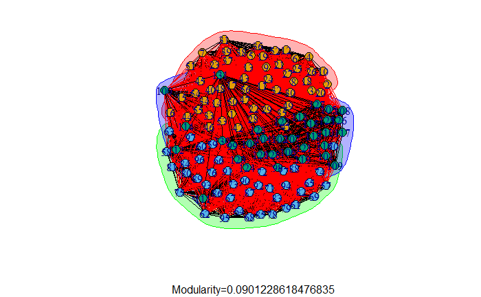

```r
V5 <- filter(Annotated, Variable=="V05")
AnalyseV5 <- dplyr::select(V5, 3,6,11,14:28)
for (k in 1:ncol(AnalyseV5)) {
  AnalyseV5[,k] <- as.factor(AnalyseV5[,k])
}
#Plot nach annotierten Kategorien
AnalyseV5 <- com_clust(AnalyseV5)
```

```r
AnalyseV5 <- AnalyseV5[[1]]
```

Merge Tags by IP

```r
# Merge Tags
V5TagMerge <- V5
remove(k)
V5TagMerge$tag <-as.character(V5TagMerge$tag)
V5TagMerge$lemma <- as.character(V5TagMerge$lemma)
for (k in nrow(V5TagMerge):2) {
  if((V5TagMerge[k,1]==V5TagMerge[k-1,1])){
    if(V5TagMerge$tag[k] != V5TagMerge$tag[k-1]){
    V5TagMerge$tag[k-1] <- stringr::str_c(V5TagMerge$tag[k-1],V5TagMerge$tag[k], sep = ":")
    V5TagMerge$lemma[k-1] <- stringr::str_c(V5TagMerge$lemma[k-1],V5TagMerge$lemma[k], sep = ":")

    }
    V5TagMerge <- V5TagMerge[-k,]
  }else{
    next()
  }

}
V5TagMerge$tag <-as.factor(V5TagMerge$tag)
V5TagMerge$lemma <-as.factor(V5TagMerge$lemma)
#V5IpTag <- cbind(SortIpV5,V5TagMerge$tag,V5TagMerge$lemma)
```

Sort by IP

```r
SortIpNA <- sort_by_unit(exb=Corpus, drop = TRUE)
SortIpNaAbsolute <- sort_by_unit(Corpus, drop=TRUE, percentage=FALSE)
```

Plot Kookkurrenz über Situationen hinweg (mit Lemma und Wortart)

[output not shown]

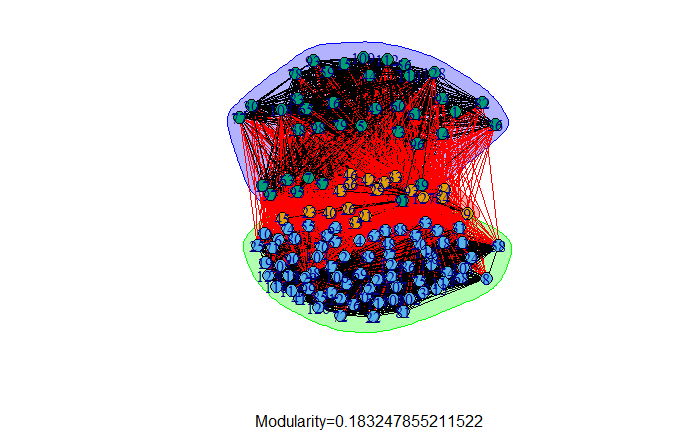

```r
SortIpV5 <- filter(SortIpNA, SortIpNA$`Variable:V05:gg`!=0|SortIpNA$`Variable:V05:ch`!=0)
SortIpV5 <- bind_cols(SortIpV5, V5TagMerge[,31:32])
#SortIpOHNEMA3 <- filter(SortIpV5,File != " Ma3" )
#SortIpV4 <- select(SortIpV4, 1,16:40)
for (p in 1:ncol(SortIpNA)) {
  SortIpNA[,p] <- as.factor(SortIpNA[,p])
}
SortIpV5 <- com_clust(SortIpV5, variables = c(16:36))
```

```r
SortIpV5 <- SortIpV5[[1]]
```

Plot Kookkurrenz über Situationen hinweg (ohne Lemma und Wortart)

```r
SortIpV5 <- com_clust(SortIpV5, variables = c(21:41))
SortIpV5 <- SortIpV5[[1]]
```

[output not shown]

Cooccurrence Plot by Situation (mit Lemma und Wortart)

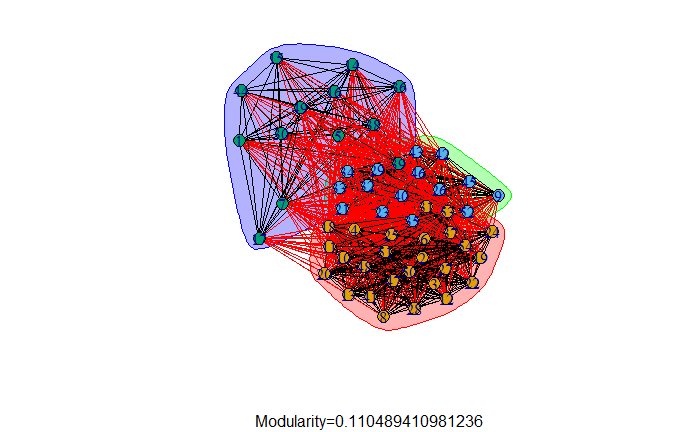

```r
#SortIpNA <- sort_by_unit(exb=Corpus, drop = TRUE)

files <- unique(SortIpV5$File)
for (k in 1:length(files)) {
  g <- filter(SortIpV5, SortIpV5$File==files[k])
    for (p in 1:ncol(g)) {
      g[,p] <- as.factor(g[,p])
    }
  name <- stringr::str_glue("SortIpV5",stringr::str_trim(files[k]))
  assign(name,g)
}
SortIpV5Ma1 <- com_clust(SortIpV5Ma1,variables = c(21:43))
```

```
no non-missing arguments to min; returning Infno non-missing arguments to max; returning -Infno non-missing arguments to min; returning Infno non-missing arguments to max; returning -Inf
```

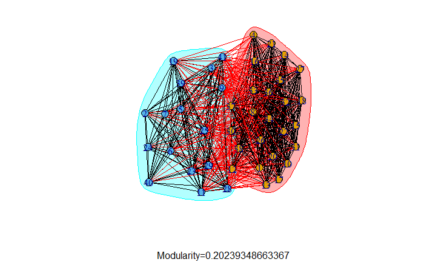

```r
SortIpV5Ma1 <- SortIpV5Ma1[[1]]
SortIpV5Ma2 <- com_clust(SortIpV5Ma2,variables = c(21:43))
```

[output not shown]

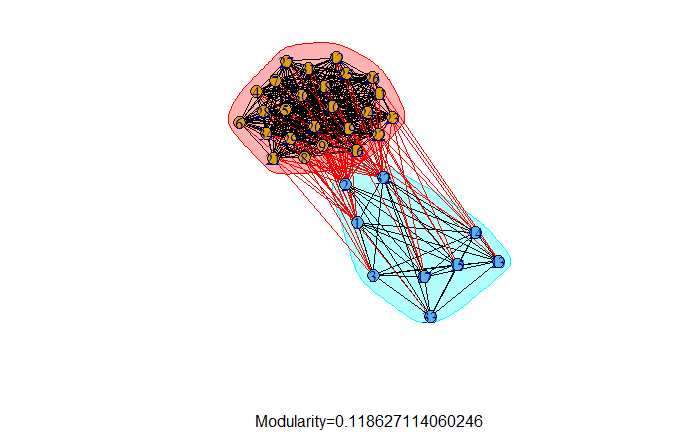

```r
SortIpV5Ma2 <- SortIpV5Ma2[[1]]
SortIpV5Ma4 <- com_clust(SortIpV5Ma4,variables = c(21:43))
```

```r
SortIpV5Ma4 <- SortIpV5Ma4[[1]]
```

Cooccurrence Plot by Situation (ohne Lemma und Wortart)

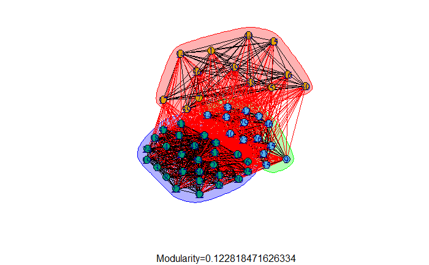

```r
#SortIpNA <- sort_by_unit(exb=Corpus, drop = TRUE)


SortIpV5Ma1 <- com_clust(SortIpV5Ma1,variables = c(21:41))
```

```
no non-missing arguments to min; returning Infno non-missing arguments to max; returning -Infno non-missing arguments to min; returning Infno non-missing arguments to max; returning -Inf
```

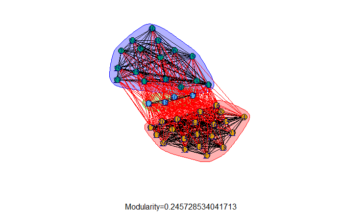

```r
SortIpV5Ma1 <- SortIpV5Ma1[[1]]
SortIpV5Ma2 <- com_clust(SortIpV5Ma2,variables = c(21:41))
```

[output not shown]

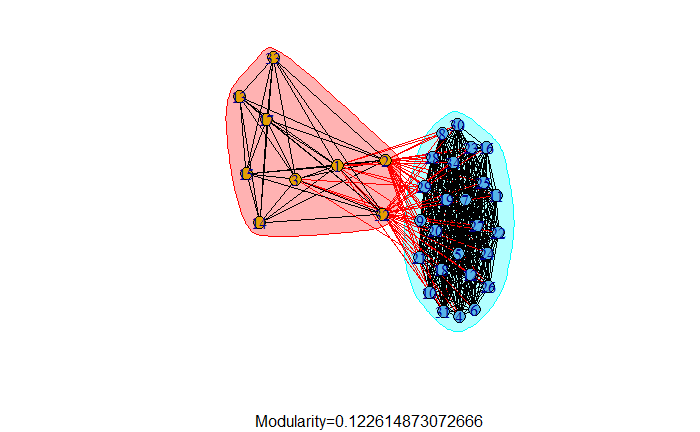

```r
SortIpV5Ma2 <- SortIpV5Ma2[[1]]
SortIpV5Ma4 <- com_clust(SortIpV5Ma4,variables = c(21:41))
```

```r
SortIpV5Ma4 <- SortIpV5Ma4[[1]]
```

Summarise by group/global (mit Lemma und Wortart)

```r
V5Sum <- SortIpV5[,21:44]
# for (k in 1:ncol(V5Ma1Sum)) {
#   for (l in 1:nrow(V5Ma1Sum)) {
#     V5Ma1Sum[l,k] <- as.character(V5Ma1Sum[l,k])
#   }
#
# }

#V5Sum <- fastDummies::dummy_columns(V5Sum, select_columns = "tag")
V5Sum <- fastDummies::dummy_columns(V5Sum, select_columns = "lemma")
V5Sum <- data.frame(lapply(V5Sum, as.character), stringsAsFactors=FALSE)
V5Sum[is.na(V5Sum)] <- 0
V5Sum <- V5Sum[,-c(22,23)]
for (k in 1: ncol(V5Sum)){
  #if(!(is.na(V5Ma1Sum[l,k]))){
  #for (l in 1:nrow(V5Ma1Sum)) {
    V5Sum[,k] <- as.numeric(V5Sum[,k])
  #}
  #}
}
#V5Ma1Sum <-  rename(V5Ma1Sum, tag=V5TagMerge.tag)
#V5Ma1Sum <- rename(V5Ma1Sum, group= as.factor.group.)
V5Sum %>%
  group_by(group)%>%
  summarise_all(sum)-> V5Summary
```

```r
#V5Sum <- rename(V5Sum, group= as.factor.group.)
# Vars <- colnames(V5Sum)
# f <- paste(Vars[24], "~", paste(Vars[-c(13,22:24,16:17,35:36)], collapse=" + "))
# corV5Sum <- cor(V5Sum[,-c(13,16:17,22:24,35,36)])
priors <- count(V5Sum, group)
priors <- c(priors$n)
V5SumLDA <- lda(V5Sum[,-c(17,18,22)], V5Sum$group, prior=priors/nrow(V5Sum))
```

```
Variablen sind kollinear
```

```r
V5SumLDA
```

```
Call:
lda(V5Sum[, -c(17, 18, 22)], V5Sum$group, prior = priors/nrow(V5Sum))

Prior probabilities of groups:
        1         2         3
0.1395349 0.5658915 0.2945736

Group means:
  Variable.V01.ä Variable.V01.e Variable.V02.k Variable.V02.l Variable.V03.e0 Variable.V03.e1 Variable.V04.tu Variable.V04.tv Variable.V05.ch
1     0.16666667     0.00000000     0.02777778    0.638888889      0.05555556      0.00000000      0.00000000       0.3888889      1.00000000
2     0.01369863     0.00000000     0.86986301    0.006849315      0.17808219      0.00000000      0.10958904       0.1917808      1.00000000
3     0.00000000     0.02631579     0.17105263    0.776315789      0.10526316      0.02631579      0.02631579       0.2894737      0.06578947
  Variable.V05.gg Variable.V06.t0 Variable.V06.t1 Variable.V07.dd Variable.V07.nd Variable.V07.nn Variable.V08.ng Variable.V09.ick
1       0.0000000       0.0000000       0.7777778      0.05555556     0.000000000     0.000000000      0.00000000       0.00000000
2       0.0000000       0.3789954       0.1689498      0.02739726     0.006849315     0.006849315      0.02739726       0.07534247
3       0.9342105       0.2587719       0.2938596      0.00000000     0.000000000     0.052631579      0.07894737       0.05263158
  Variable.V10.P0 Variable.V10.P1 lemma_abfragen lemma_ausgelegt lemma_beruhigen lemma_beruhigt lemma_dienstag lemma_dienstags lemma_Donnerstag
1      0.00000000      0.33333333     0.05555556      0.05555556      0.00000000     0.00000000     0.00000000      0.00000000       0.00000000
2      0.09589041      0.19178082     0.00000000      0.00000000      0.00000000     0.00000000     0.01369863      0.01369863       0.01369863
3      0.00000000      0.07894737     0.00000000      0.00000000      0.02631579     0.02631579     0.00000000      0.00000000       0.00000000
  lemma_donnerstags lemma_erzeugen lemma_fragen lemma_freitag lemma_Freitag lemma_freitags lemma_genug lemma_gesagt lemma_hinkriegen
1        0.00000000     0.00000000   0.00000000    0.00000000    0.00000000     0.00000000  0.00000000   0.00000000       0.00000000
2        0.01369863     0.00000000   0.04109589    0.02739726    0.00000000     0.01369863  0.00000000   0.01369863       0.01369863
3        0.00000000     0.02631579   0.05263158    0.00000000    0.02631579     0.00000000  0.02631579   0.00000000       0.00000000
  lemma_kampftag lemma_kriegen lemma_legen lemma_liegen lemma_mauberg lemma_mitberücksichtigen lemma_mitkriegen lemma_mögen lemma_montag
1     0.00000000    0.00000000  0.00000000   0.05555556    0.00000000               0.05555556       0.00000000  0.00000000   0.05555556
2     0.00000000    0.06849315  0.00000000   0.01369863    0.00000000               0.00000000       0.01369863  0.04109589   0.02739726
3     0.05263158    0.10526316  0.05263158   0.05263158    0.02631579               0.00000000       0.00000000  0.05263158   0.00000000
  lemma_montags lemma_nachfragen lemma_ruhig lemma_rundweg lemma_sagen lemma_sagen.erlebniswandertag lemma_sargen lemma_segg lemma_Sonntag
1    0.00000000       0.00000000  0.05555556    0.00000000  0.55555556                    0.00000000   0.00000000 0.00000000    0.00000000
2    0.02739726       0.01369863  0.00000000    0.00000000  0.49315068                    0.01369863   0.00000000 0.00000000    0.04109589
3    0.02631579       0.00000000  0.00000000    0.02631579  0.07894737                    0.00000000   0.02631579 0.02631579    0.02631579
  lemma_sonntags lemma_steigen lemma_tagen lemma_Umweg lemma_Umzug lemma_unterwegs lemma_vorliegen lemma_Vorschlag  lemma_weg
1     0.00000000    0.00000000  0.00000000  0.00000000  0.00000000      0.00000000      0.00000000      0.00000000 0.11111111
2     0.01369863    0.00000000  0.04109589  0.00000000  0.01369863      0.00000000      0.00000000      0.01369863 0.00000000
3     0.05263158    0.02631579  0.05263158  0.02631579  0.00000000      0.02631579      0.02631579      0.02631579 0.02631579

Coefficients of linear discriminants:
                                       LD1         LD2
Variable.V01.ä                 0.863050425  2.67421547
```

[output cut: 50 more lines]

```
lemma_segg                     2.034712168  3.48810213
lemma_Sonntag                 -0.317994076 -0.31600002
lemma_sonntags                -0.216848880 -0.23083222
lemma_steigen                  1.925426787  0.74928512
lemma_tagen                   -0.769358422 -0.12118825
lemma_Umweg                   -1.111866084  0.02384988
lemma_Umzug                   -0.731193321  0.57707442
lemma_unterwegs               -0.343739801 -0.41524041
lemma_vorliegen               -1.876824982 -0.90223102
lemma_Vorschlag               -0.153403419 -0.13862813
lemma_weg                      0.425185197  3.43159360

Proportion of trace:
   LD1    LD2
0.8358 0.1642
```

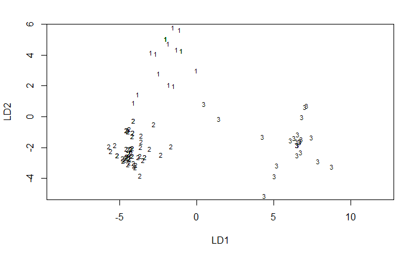

```r
plot(V5SumLDA)
```

```r
V5SumLDAScal <- as.data.frame(V5SumLDA$scaling)
V5SumLDAScal[,3] <-V5SumLDAScal$LD1- V5SumLDAScal$LD2
V5SumLDAScal
```

|  | LD1 | LD2 | V3 |
| --- | --- | --- | --- |
| Variable.V01.ä | 0.863050425 | 2.67421547 | -1.811165042 |
| Variable.V01.e | -0.341300834 | -1.98212248 | 1.640821648 |
| Variable.V02.k | -0.342124662 | -1.86196717 | 1.519842504 |
| Variable.V02.l | 2.540075696 | 2.86632791 | -0.326252213 |
| Variable.V03.e0 | -0.426569303 | 0.14701238 | -0.573581681 |
| Variable.V03.e1 | 0.885167137 | 2.37607248 | -1.490905340 |
| Variable.V04.tu | 0.369351434 | -0.04977981 | 0.419131249 |
| Variable.V04.tv | 0.254967963 | 0.56008943 | -0.305121470 |
| Variable.V05.ch | -4.203899114 | 1.80969029 | -6.013589407 |
| Variable.V05.gg | 4.203899114 | -1.80969029 | 6.013589407 |

[output cut: 52 more lines]

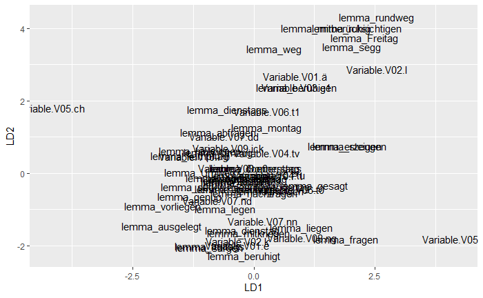

```r
rownumbers <- row(V5SumLDAScal)
ggplot(data=V5SumLDAScal, aes(x=LD1, y=LD2))+geom_text(aes(label=rownames(V5SumLDAScal)))
```

discriminant analysis global (ohne Lemma und Wortart)

```r
#V5Sum <- rename(V5Sum, group= as.factor.group.)
# Vars <- colnames(V5Sum)
# f <- paste(Vars[24], "~", paste(Vars[-c(13,22:24,16:17,35:36)], collapse=" + "))
# corV5Sum <- cor(V5Sum[,-c(13,16:17,22:24,35,36)])
priors <- count(V5Sum, group)
priors <- c(priors$n)
V5SumLDA <- lda(V5Sum[,-c(17,18,22:65)], V5Sum$group, prior=priors/nrow(V5Sum))
```

```
Variablen sind kollinear
```

```r
V5SumLDA
```

```
Call:
lda(V5Sum[, -c(17, 18, 22:65)], V5Sum$group, prior = priors/nrow(V5Sum))

Prior probabilities of groups:
        1         2         3
0.1395349 0.5658915 0.2945736

Group means:
  Variable.V01.ä Variable.V01.e Variable.V02.k Variable.V02.l Variable.V03.e0 Variable.V03.e1 Variable.V04.tu Variable.V04.tv Variable.V05.ch
1     0.16666667     0.00000000     0.02777778    0.638888889      0.05555556      0.00000000      0.00000000       0.3888889      1.00000000
2     0.01369863     0.00000000     0.86986301    0.006849315      0.17808219      0.00000000      0.10958904       0.1917808      1.00000000
3     0.00000000     0.02631579     0.17105263    0.776315789      0.10526316      0.02631579      0.02631579       0.2894737      0.06578947
  Variable.V05.gg Variable.V06.t0 Variable.V06.t1 Variable.V07.dd Variable.V07.nd Variable.V07.nn Variable.V08.ng Variable.V09.ick
1       0.0000000       0.0000000       0.7777778      0.05555556     0.000000000     0.000000000      0.00000000       0.00000000
2       0.0000000       0.3789954       0.1689498      0.02739726     0.006849315     0.006849315      0.02739726       0.07534247
3       0.9342105       0.2587719       0.2938596      0.00000000     0.000000000     0.052631579      0.07894737       0.05263158
  Variable.V10.P0 Variable.V10.P1
1      0.00000000      0.33333333
2      0.09589041      0.19178082
3      0.00000000      0.07894737

Coefficients of linear discriminants:
                         LD1        LD2
Variable.V01.ä   -0.12641782  2.0256217
Variable.V01.e   -0.25337603 -1.7182477
Variable.V02.k   -0.56599417 -1.5093410
Variable.V02.l    1.26898185  1.6926864
Variable.V03.e0  -0.28603503 -0.1577618
Variable.V03.e1   1.02558079  3.3749493
Variable.V04.tu  -0.13714626 -0.3536343
Variable.V04.tv   0.20164289  0.3237242
Variable.V05.ch  -3.86936413  1.1507775
Variable.V05.gg   3.86936413 -1.1507775
Variable.V06.t0   0.50221905 -0.5482949
Variable.V06.t1  -0.05380015  1.3428748
Variable.V07.dd  -0.52490861  0.9545964
Variable.V07.nd  -0.06549326 -1.3893985
Variable.V07.nn  -0.43233197 -1.1272362
Variable.V08.ng   0.35044486 -1.1525555
Variable.V09.ick  0.08792770  0.8669084
Variable.V10.P0  -0.25532656 -0.4530149
Variable.V10.P1   0.28406249 -0.3741957

Proportion of trace:
   LD1    LD2
0.9004 0.0996
```

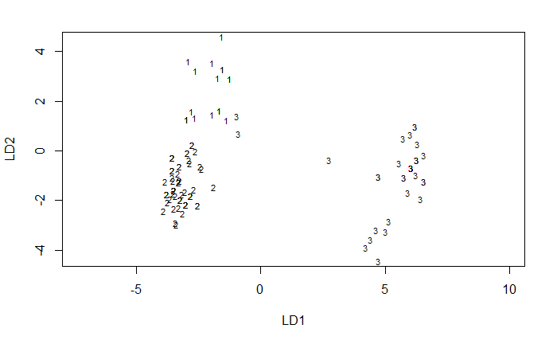

```r
plot(V5SumLDA)
```

```r
V5SumLDAScal <- as.data.frame(V5SumLDA$scaling)
V5SumLDAScal[,3] <-V5SumLDAScal$LD1- V5SumLDAScal$LD2
V5SumLDAScal
```

|  | LD1 | LD2 | V3 |
| --- | --- | --- | --- |
| Variable.V01.ä | -0.12641782 | 2.0256217 | -2.1520395 |
| Variable.V01.e | -0.25337603 | -1.7182477 | 1.4648717 |
| Variable.V02.k | -0.56599417 | -1.5093410 | 0.9433468 |
| Variable.V02.l | 1.26898185 | 1.6926864 | -0.4237046 |
| Variable.V03.e0 | -0.28603503 | -0.1577618 | -0.1282732 |
| Variable.V03.e1 | 1.02558079 | 3.3749493 | -2.3493685 |
| Variable.V04.tu | -0.13714626 | -0.3536343 | 0.2164880 |
| Variable.V04.tv | 0.20164289 | 0.3237242 | -0.1220813 |
| Variable.V05.ch | -3.86936413 | 1.1507775 | -5.0201416 |
| Variable.V05.gg | 3.86936413 | -1.1507775 | 5.0201416 |

[output cut: 9 more lines]

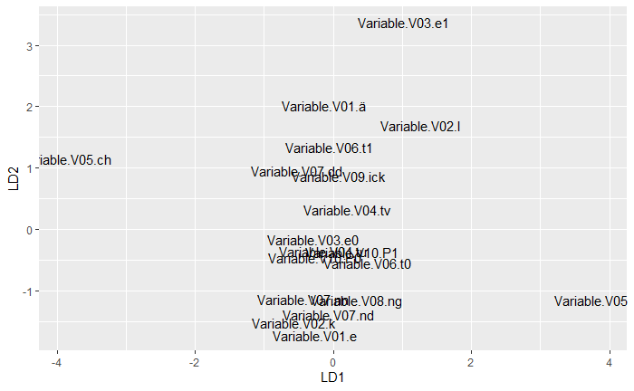

```r
rownumbers <- row(V5SumLDAScal)
ggplot(data=V5SumLDAScal, aes(x=LD1, y=LD2))+geom_text(aes(label=rownames(V5SumLDAScal)))
```

```r
V5SumMa4 <- fastDummies::dummy_columns(V5SumMa4, select_columns = "tag")
```

[output not shown]

LDA group/Situation (mit Lemma und Wortart)

```r
#V5SumMa1 <- rename(V5SumMa1, group= as.factor.group.)
V5SumMa1 <- mutate_if(V5SumMa1, is.double, as.integer)
#V5SumMa2 <- rename(V5SumMa4, group= as.factor.group.)
V5SumMa2 <- mutate_if(V5SumMa2, is.double, as.integer)
#V5SumMa4 <- rename(V5SumMa4, group= as.factor.group.)
V5SumMa4 <- mutate_if(V5SumMa4, is.double, as.integer)
```

```r
V5SumMa1 <- V5SumMa1[,which(colSums(V5SumMa1)>0)]#Variablen ausschließen, die nie auftreten und durch ihre Konstanz fehlermeldung verursachen
# Vars <- colnames(V5SumMa1)
#f <- paste(Vars[15], "~", paste(Vars[-c(15)], collapse=" + "))
corV5SumMa1 <- cor(V5SumMa1[,-c(16:18)])
priors <- count(V5SumMa1, group)
priors <- c(priors$n)

V5SumMa1LDA <- lda(V5SumMa1[,-which(names(V5SumMa1) =="group")],V5SumMa1$group, prior=priors/nrow(V5SumMa1))
```

```
Variablen sind kollinear
```

```r
V5SumMa1LDA
```

```
Call:
lda(V5SumMa1[, -which(names(V5SumMa1) == "group")], V5SumMa1$group,
    prior = priors/nrow(V5SumMa1))

Prior probabilities of groups:
        1         2         3
0.2592593 0.5000000 0.2407407

Group means:
  Variable.V01.ä Variable.V02.k Variable.V02.l Variable.V03.e0 Variable.V04.tv Variable.V05.ch Variable.V05.gg Variable.V06.t0 Variable.V06.t1
1      0.1428571      0.0000000      0.5000000      0.00000000       0.5000000      1.00000000       0.0000000       0.0000000       0.9285714
2      0.0000000      0.7777778      0.0000000      0.11111111       0.3703704      1.00000000       0.0000000       0.2592593       0.1111111
3      0.0000000      0.1538462      0.7692308      0.07692308       0.4615385      0.07692308       0.8461538       0.1538462       0.3076923
  Variable.V07.dd Variable.V07.nn Variable.V08.ng Variable.V09.ich Variable.V10.P1 lemma_abfragen lemma_dienstag lemma_dienstags
1      0.07142857      0.00000000      0.00000000       0.00000000      0.28571429     0.07142857     0.00000000      0.00000000
2      0.03703704      0.00000000      0.07407407       0.03703704      0.07407407     0.00000000     0.03703704      0.03703704
3      0.00000000      0.07692308      0.23076923       0.00000000      0.00000000     0.00000000     0.00000000      0.00000000
  lemma_Donnerstag lemma_donnerstags lemma_erzeugen lemma_freitag lemma_Freitag lemma_freitags lemma_kampftag lemma_kriegen lemma_liegen
1       0.00000000        0.00000000     0.00000000    0.00000000    0.00000000     0.00000000      0.0000000    0.00000000   0.07142857
2       0.03703704        0.03703704     0.00000000    0.03703704    0.00000000     0.03703704      0.0000000    0.03703704   0.00000000
3       0.00000000        0.00000000     0.07692308    0.00000000    0.07692308     0.00000000      0.1538462    0.07692308   0.07692308
  lemma_mitberücksichtigen lemma_mögen lemma_montag lemma_ruhig lemma_rundweg lemma_sagen lemma_sagen.erlebniswandertag lemma_tagen
1               0.07142857   0.0000000   0.07142857  0.07142857    0.00000000   0.5714286                    0.00000000  0.00000000
2               0.00000000   0.0000000   0.00000000  0.00000000    0.00000000   0.5925926                    0.03703704  0.07407407
3               0.00000000   0.1538462   0.00000000  0.00000000    0.07692308   0.0000000                    0.00000000  0.15384615
  lemma_vorliegen lemma_Vorschlag  lemma_weg
1      0.00000000      0.00000000 0.07142857
2      0.00000000      0.03703704 0.00000000
3      0.07692308      0.07692308 0.00000000

Coefficients of linear discriminants:
                                       LD1         LD2
Variable.V01.ä                  1.87541797  1.98275926
Variable.V02.k                 -0.96018119 -2.29788565
Variable.V02.l                  1.90456396  1.65396568
Variable.V03.e0                 0.85796170  1.11939213
Variable.V04.tv                -0.17785178  0.63729990
Variable.V05.ch               -10.80536913  2.08742739
Variable.V05.gg                -0.93494767 -1.45543991
Variable.V06.t0                 1.01057996 -0.36035351
```

[output cut: 18 more lines]

```
lemma_mitberücksichtigen        1.23813940  2.20556195
lemma_mögen                    -0.48290178  0.40476587
lemma_montag                    1.23813940  2.20556195
lemma_ruhig                     1.23813940  2.20556195
lemma_rundweg                   2.20399159  4.99391710
lemma_sagen                    -0.56426929 -0.89681603
lemma_sagen.erlebniswandertag  -0.07223877 -0.40257093
lemma_tagen                    -0.94213034  0.31921031
lemma_vorliegen                 0.50093333 -2.16481638
lemma_Vorschlag                -0.45542206  0.63839737
lemma_weg                      -0.71531201  4.57661843

Proportion of trace:
   LD1    LD2
0.6941 0.3059
```

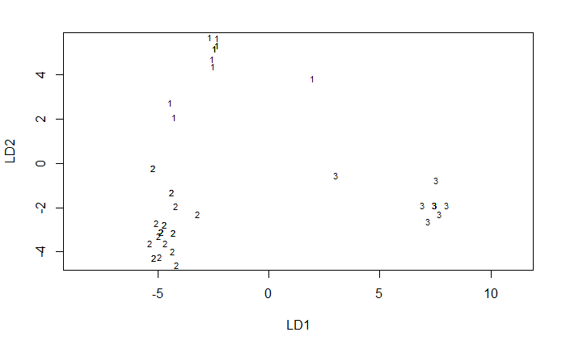

```r
plot(V5SumMa1LDA)
```

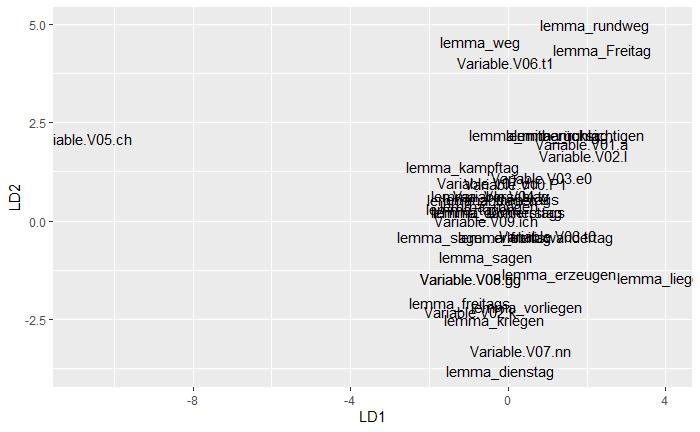

```r
V5SumMa1LDAScal <- as.data.frame(V5SumMa1LDA$scaling)
V5SumMa1LDAScal[,3] <-V5SumMa1LDAScal$LD1- V5SumMa1LDAScal$LD2
ggplot(data=V5SumMa1LDAScal, aes(x=LD1, y=LD2))+geom_text(aes(label=rownames(V5SumMa1LDAScal)))
```

LDA Ma1 ohne Lemma und Wortart

```r
V5SumMa1 <- V5SumMa1[,which(colSums(V5SumMa1)>0)]#Variablen ausschließen, die nie auftreten und durch ihre Konstanz fehlermeldung verursachen
# Vars <- colnames(V5SumMa1)
#f <- paste(Vars[15], "~", paste(Vars[-c(15)], collapse=" + "))
corV5SumMa1 <- cor(V5SumMa1[,-c(16:18)])
priors <- count(V5SumMa1, group)
priors <- c(priors$n)

V5SumMa1LDA <- lda(V5SumMa1[,-c(15:38)],V5SumMa1$group, prior=priors/nrow(V5SumMa1))
V5SumMa1LDA
```

```
Call:
lda(V5SumMa1[, -c(15:38)], V5SumMa1$group, prior = priors/nrow(V5SumMa1))

Prior probabilities of groups:
        1         2         3
0.2592593 0.5000000 0.2407407

Group means:
  Variable.V01.ä Variable.V02.k Variable.V02.l Variable.V03.e0 Variable.V04.tv Variable.V05.ch Variable.V05.gg Variable.V06.t0 Variable.V06.t1
1      0.1428571      0.0000000      0.5000000      0.00000000       0.5000000      1.00000000       0.0000000       0.0000000       0.9285714
2      0.0000000      0.7777778      0.0000000      0.11111111       0.3703704      1.00000000       0.0000000       0.2592593       0.1111111
3      0.0000000      0.1538462      0.7692308      0.07692308       0.4615385      0.07692308       0.8461538       0.1538462       0.3076923
  Variable.V07.dd Variable.V07.nn Variable.V08.ng Variable.V09.ich Variable.V10.P1
1      0.07142857      0.00000000      0.00000000       0.00000000      0.28571429
2      0.03703704      0.00000000      0.07407407       0.03703704      0.07407407
3      0.00000000      0.07692308      0.23076923       0.00000000      0.00000000

Coefficients of linear discriminants:
                         LD1         LD2
Variable.V01.ä    0.38199331  1.62678049
Variable.V02.k   -0.32292342 -1.59177698
Variable.V02.l    1.05037017  1.19614735
Variable.V03.e0   0.44739790  0.77487174
Variable.V04.tv   0.20425161 -0.05952713
Variable.V05.ch  -7.98952665 -0.08642274
Variable.V05.gg  -0.16968759 -1.07702827
Variable.V06.t0   0.85023556 -0.39789143
Variable.V06.t1  -0.06008102  2.04986075
Variable.V07.dd  -0.51371497  0.31896432
Variable.V07.nn  -0.26622384 -2.36467878
Variable.V08.ng  -0.70024407 -1.33231917
Variable.V09.ich -0.31339268 -0.78747428
Variable.V10.P1  -0.30585129  0.23693250

Proportion of trace:
   LD1    LD2
0.8108 0.1892
```

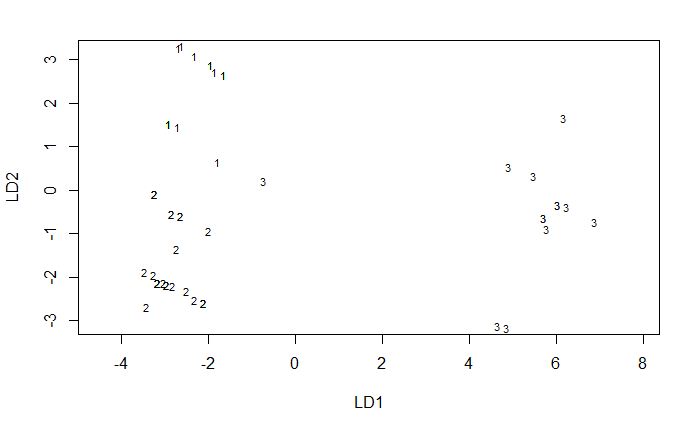

```r
plot(V5SumMa1LDA)
```

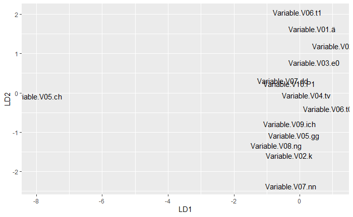

```r
V5SumMa1LDAScal <- as.data.frame(V5SumMa1LDA$scaling)
V5SumMa1LDAScal[,3] <-V5SumMa1LDAScal$LD1- V5SumMa1LDAScal$LD2
ggplot(data=V5SumMa1LDAScal, aes(x=LD1, y=LD2))+geom_text(aes(label=rownames(V5SumMa1LDAScal)))
```

LDA Ma2 mit Lemma und Wortart

```r
V5SumMa2 <- V5SumMa2[,which(colSums(V5SumMa2)>0)]

corV5SumMa2 <- cor(V5SumMa2[,-14])
priors <- count(V5SumMa2, group)
priors <- c(priors$n)
V5SumMa2LDA <- lda(V5SumMa2[,-which(names(V5SumMa2) =="group")],V5SumMa2$group, prior=priors/nrow(V5SumMa2))
```

```
Variablen sind kollinear
```

```r
V5SumMa2LDA
```

```
Call:
lda(V5SumMa2[, -which(names(V5SumMa2) == "group")], V5SumMa2$group,
    prior = priors/nrow(V5SumMa2))

Prior probabilities of groups:
         1          2          3
0.07317073 0.51219512 0.41463415

Group means:
  Variable.V01.ä Variable.V01.e Variable.V02.k Variable.V02.l Variable.V03.e0 Variable.V04.tu Variable.V04.tv Variable.V05.ch Variable.V05.gg
1     0.33333333     0.00000000      0.0000000      1.0000000      0.00000000      0.00000000       0.0000000      1.00000000       0.0000000
2     0.04761905     0.00000000      0.9047619      0.0000000      0.28571429      0.00000000       0.1904762      1.00000000       0.0000000
3     0.00000000     0.05882353      0.1764706      0.7058824      0.05882353      0.05882353       0.2941176      0.05882353       0.9411765
  Variable.V06.t0 Variable.V06.t1 Variable.V07.dd Variable.V09.ich Variable.V09.ick Variable.V10.P1  tag_ADJD   tag_ADV    tag_NE     tag_NN
1       0.0000000       0.3333333      0.00000000        0.0000000       0.00000000       0.6666667 0.3333333 0.0000000 0.0000000 0.00000000
2       0.3333333       0.2857143      0.04761905        0.2380952       0.00000000       0.5714286 0.0000000 0.0000000 0.0000000 0.00000000
3       0.2352941       0.2352941      0.00000000        0.0000000       0.05882353       0.1764706 0.0000000 0.1764706 0.1176471 0.05882353
  tag_VVFIN  tag_VVIMP  tag_VVPP lemma_ausgelegt lemma_fragen lemma_genug lemma_kriegen lemma_legen lemma_liegen lemma_mauberg lemma_mitkriegen
1 0.0000000 0.00000000 0.6666667       0.3333333    0.0000000  0.00000000    0.00000000   0.0000000   0.00000000    0.00000000       0.00000000
2 0.3333333 0.04761905 0.6190476       0.0000000    0.0000000  0.00000000    0.14285714   0.0000000   0.04761905    0.00000000       0.04761905
3 0.2941176 0.17647059 0.1764706       0.0000000    0.1176471  0.05882353    0.05882353   0.1176471   0.05882353    0.05882353       0.00000000
  lemma_nachfragen lemma_sagen lemma_sargen lemma_segg lemma_steigen lemma_tagen lemma_Umweg lemma_unterwegs  lemma_weg
1       0.00000000   0.6666667   0.00000000 0.00000000    0.00000000  0.00000000  0.00000000      0.00000000 0.00000000
2       0.04761905   0.6666667   0.00000000 0.00000000    0.00000000  0.04761905  0.00000000      0.00000000 0.00000000
3       0.00000000   0.1764706   0.05882353 0.05882353    0.05882353  0.00000000  0.05882353      0.05882353 0.05882353

Coefficients of linear discriminants:
                         LD1         LD2
Variable.V01.ä   -0.82506323  -4.7263788
Variable.V01.e   -0.86194931 -11.6154730
Variable.V02.k    0.83022476  -0.7159237
Variable.V02.l    5.74955543   6.1648922
Variable.V03.e0   4.92551919  -3.2586986
Variable.V04.tu  -0.67103733  -2.1675688
Variable.V04.tv  -0.02413133  -4.6755173
Variable.V05.ch  -4.12631664  -0.8909248
Variable.V05.gg   4.12631664   0.8909248
Variable.V06.t0   0.75510095   3.7980088
Variable.V06.t1   0.08374403  -1.5552650
Variable.V07.dd  -3.33292538   0.5529439
```

[output cut: 16 more lines]

```
lemma_mauberg    -1.19486893  -5.1990688
lemma_mitkriegen -1.41430033   2.2623708
lemma_nachfragen -3.33292538   0.5529439
lemma_sagen      -0.91526833   2.5735681
lemma_sargen     -0.61798590  -0.7228769
lemma_segg        1.49674606   1.2796278
lemma_steigen     5.09792276   1.8373938
lemma_tagen      -0.48943792  -1.3280772
lemma_Umweg      -0.89448437  -5.5437230
lemma_unterwegs  -1.34207467  -4.3351376
lemma_weg         2.82215505  -1.2523305

Proportion of trace:
   LD1    LD2
0.8277 0.1723
```

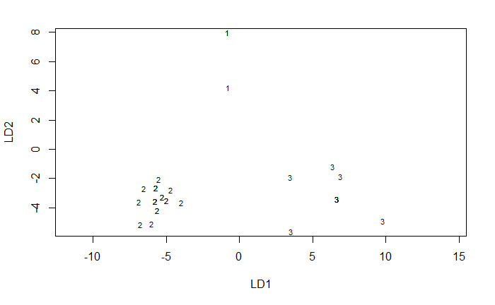

```r
plot(V5SumMa2LDA)
```

```r
V5SumMa2LDAScal <- as.data.frame(V5SumMa2LDA$scaling)
V5SumMa2LDAScal[,3] <-V5SumMa2LDAScal$LD1- V5SumMa2LDAScal$LD2
```

LDA Ma2 ohne Lemma und Wortart

```r
V5SumMa2 <- V5SumMa2[,which(colSums(V5SumMa2)>0)]

corV5SumMa2 <- cor(V5SumMa2[,-14])
priors <- count(V5SumMa2, group)
priors <- c(priors$n)
V5SumMa2LDA <- lda(V5SumMa2[,-c(16:40)],V5SumMa2$group, prior=priors/nrow(V5SumMa2))
```

```
Variablen sind kollinear
```

```r
V5SumMa2LDA
```

```
Call:
lda(V5SumMa2[, -c(16:40)], V5SumMa2$group, prior = priors/nrow(V5SumMa2))

Prior probabilities of groups:
         1          2          3
0.07317073 0.51219512 0.41463415

Group means:
  Variable.V01.ä Variable.V01.e Variable.V02.k Variable.V02.l Variable.V03.e0 Variable.V04.tu Variable.V04.tv Variable.V05.ch Variable.V05.gg
1     0.33333333     0.00000000      0.0000000      1.0000000      0.00000000      0.00000000       0.0000000      1.00000000       0.0000000
2     0.04761905     0.00000000      0.9047619      0.0000000      0.28571429      0.00000000       0.1904762      1.00000000       0.0000000
3     0.00000000     0.05882353      0.1764706      0.7058824      0.05882353      0.05882353       0.2941176      0.05882353       0.9411765
  Variable.V06.t0 Variable.V06.t1 Variable.V07.dd Variable.V09.ich Variable.V09.ick Variable.V10.P1
1       0.0000000       0.3333333      0.00000000        0.0000000       0.00000000       0.6666667
2       0.3333333       0.2857143      0.04761905        0.2380952       0.00000000       0.5714286
3       0.2352941       0.2352941      0.00000000        0.0000000       0.05882353       0.1764706

Coefficients of linear discriminants:
                         LD1         LD2
Variable.V01.ä   -0.94896294  2.14784813
Variable.V01.e   -0.52188750 -1.00056144
Variable.V02.k   -0.57493673 -0.72408389
Variable.V02.l    1.81584313  2.49648475
Variable.V03.e0   0.90688479  1.94655443
Variable.V04.tu  -0.43185687 -0.88294531
Variable.V04.tv  -0.32279566 -0.02189122
Variable.V05.ch  -3.35706197  1.30621168
Variable.V05.gg   3.35706197 -1.30621168
Variable.V06.t0   0.97955485 -0.79499512
Variable.V06.t1   0.09003063  0.11761613
Variable.V07.dd  -2.17924600 -1.51787341
Variable.V09.ich -1.37376726 -2.50246195
Variable.V09.ick  1.30216380  3.15450967
Variable.V10.P1   0.47710147 -0.33301499

Proportion of trace:
   LD1    LD2
0.9304 0.0696
```

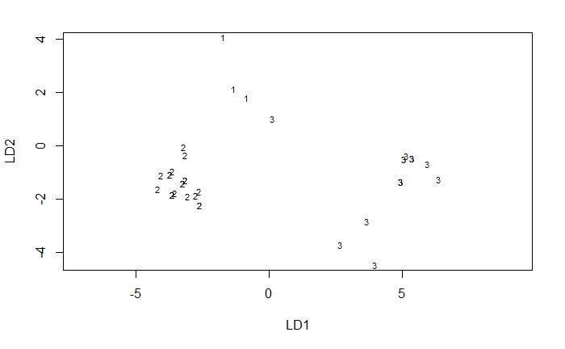

```r
plot(V5SumMa2LDA)
```

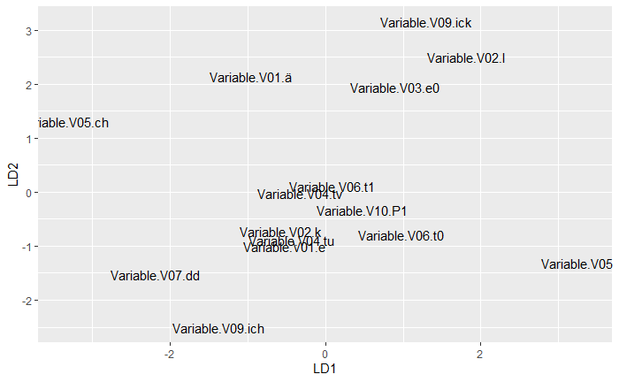

```r
V5SumMa2LDAScal <- as.data.frame(V5SumMa2LDA$scaling)
V5SumMa2LDAScal[,3] <-V5SumMa2LDAScal$LD1- V5SumMa2LDAScal$LD2
ggplot(data=V5SumMa2LDAScal, aes(x=LD1, y=LD2))+geom_text(aes(label=rownames(V5SumMa2LDAScal)))
```

LDA Ma4 mit Lemma und Wortart

```r
V5SumMa4 <- V5SumMa4[,which(colSums(V5SumMa4)>0)]
priors <- count(V5SumMa4, group)
priors <- c(priors$n)
V5SumMa4 <- V5SumMa4[,-c(6,7,38)] # konstante Variablen ausschließen
V5SumMa4LDA <- lda(V5SumMa4[,-which(names(V5SumMa4) =="group")],V5SumMa4$group, prior=priors/nrow(V5SumMa4))
```

```
Variablen sind kollinear
```

```r
V5SumMa4LDA
```

```
Call:
lda(V5SumMa4[, -which(names(V5SumMa4) == "group")], V5SumMa4$group,
    prior = priors/nrow(V5SumMa4))

Prior probabilities of groups:
         1          2          3
0.02941176 0.73529412 0.23529412

Group means:
  Variable.V02.k Variable.V02.l Variable.V03.e0 Variable.V03.e1 Variable.V04.tu Variable.V07.nn Variable.V09.ich Variable.V09.ick
1          0.000          1.000            1.00           0.000            0.00           0.000            0.000            0.000
2          0.920          0.000            0.16           0.000            0.32           0.000            0.000            0.200
3          0.125          0.875            0.25           0.125            0.00           0.125            0.125            0.125
  Variable.V10.P0 tag_ADJA tag_ADJD tag_ADV tag_NE tag_NN tag_VMFIN tag_VVFIN tag_VVIMP tag_VVPP lemma_beruhigen lemma_beruhigt lemma_fragen
1            0.00     0.00    0.000   1.000  0.000   0.00      0.00     0.000     0.000    0.000           0.000          0.000         0.00
2            0.28     0.08    0.040   0.160  0.040   0.12      0.12     0.240     0.000    0.200           0.000          0.000         0.12
3            0.00     0.00    0.125   0.375  0.125   0.00      0.00     0.125     0.125    0.125           0.125          0.125         0.00
  lemma_freitag lemma_gesagt lemma_hinkriegen lemma_kriegen lemma_mögen lemma_montag lemma_montags lemma_sagen lemma_Sonntag lemma_sonntags
1          0.00         0.00             0.00          0.00        0.00         0.00         0.000        0.00         0.000           0.00
2          0.04         0.04             0.04          0.04        0.12         0.08         0.080        0.24         0.120           0.04
3          0.00         0.00             0.00          0.25        0.00         0.00         0.125        0.00         0.125           0.25
  lemma_Umzug
1        0.00
2        0.04
3        0.00

Coefficients of linear discriminants:
                         LD1        LD2
Variable.V02.k    8.84231909  2.3660392
Variable.V02.l    3.52642242  2.0136373
Variable.V03.e0  -4.45662180 -7.1096965
Variable.V03.e1  -3.52642242 -2.0136373
Variable.V04.tu  -0.38342741 -2.2579508
Variable.V07.nn   2.12360002  9.4164936
Variable.V09.ich -3.52642242 -2.0136373
Variable.V09.ick  0.95799722  0.1007528
Variable.V10.P0  -4.47981538 -7.3011026
tag_ADJA         -0.98587697 -0.2898606
tag_ADJD          0.93404944  2.2494910
tag_ADV          -1.35903360 -2.2393223
```

[output cut: 9 more lines]

```
lemma_freitag    -0.89841094 -3.8088244
lemma_gesagt      1.70927017  1.2038529
lemma_hinkriegen -1.76142316 -1.2846886
lemma_kriegen    -2.29155271 -3.5327302
lemma_mögen      -1.10838742 -1.2024221
lemma_montag     -0.70845755 -2.8212471
lemma_montags    -1.05577875 -1.0486397
lemma_sagen      -0.28274856  1.2271409
lemma_Sonntag    -1.08086240 -1.6765740
lemma_sonntags   -1.58377188 -0.2282817
lemma_Umzug      -1.08501360 -1.6837477

Proportion of trace:
   LD1    LD2
0.8612 0.1388
```

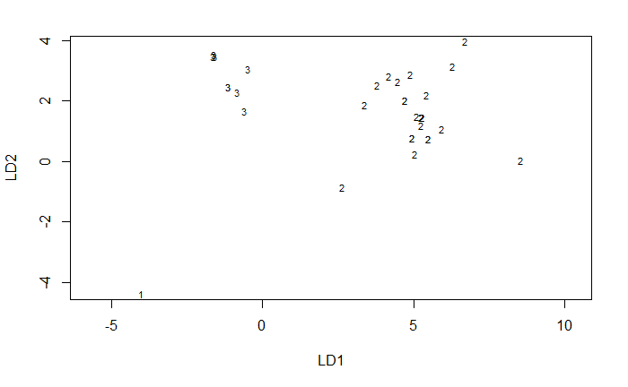

```r
plot(V5SumMa4LDA)
```

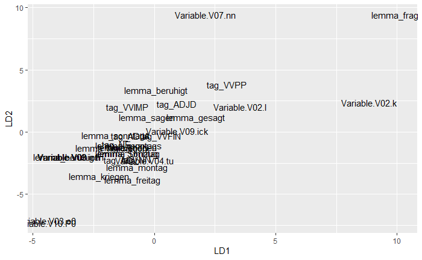

```r
V5SumMa4LDAScal <- as.data.frame(V5SumMa4LDA$scaling)
V5SumMa4LDAScal[,3] <-V5SumMa4LDAScal$LD1- V5SumMa4LDAScal$LD2
ggplot(data=V5SumMa4LDAScal, aes(x=LD1, y=LD2))+geom_text(aes(label=rownames(V5SumMa4LDAScal)))
```

LDA Ma4 ohne Lemma und Wortart

```r
V5SumMa4 <- V5SumMa4[,which(colSums(V5SumMa4)>0)]
priors <- count(V5SumMa4, group)
priors <- c(priors$n)
#V5SumMa4 <- V5SumMa4[,-c(6,7,10:33)] # konstante Variablen ausschließen
V5SumMa4LDA <- lda(V5SumMa4[,-c(6,7,10:38)],V5SumMa4$group, prior=priors/nrow(V5SumMa4))
```

```
Variablen sind kollinear
```

```r
V5SumMa4LDA
```

```
Call:
lda(V5SumMa4[, -c(6, 7, 10:38)], V5SumMa4$group, prior = priors/nrow(V5SumMa4))

Prior probabilities of groups:
         1          2          3
0.02941176 0.73529412 0.23529412

Group means:
  Variable.V02.k Variable.V02.l Variable.V03.e0 Variable.V03.e1 Variable.V04.tu Variable.V06.t0 Variable.V06.t1
1          0.000          1.000            1.00           0.000            0.00            0.00            0.00
2          0.920          0.000            0.16           0.000            0.32            0.40            0.00
3          0.125          0.875            0.25           0.125            0.00            0.25            0.25

Coefficients of linear discriminants:
                       LD1        LD2
Variable.V02.k   2.5558137 -0.6696688
Variable.V02.l  -0.9798207 -0.8411880
Variable.V03.e0  0.5264803 -2.4097502
Variable.V03.e1  0.9798207  0.8411880
Variable.V04.tu  0.7633374 -0.0973074
Variable.V06.t0 -0.3322191  1.0521071
Variable.V06.t1 -1.0042100  2.9946314

Proportion of trace:
   LD1    LD2
0.8947 0.1053
```

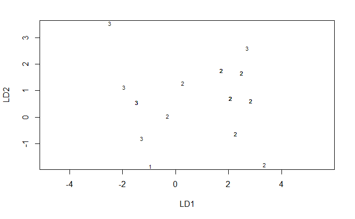

```r
plot(V5SumMa4LDA)
```

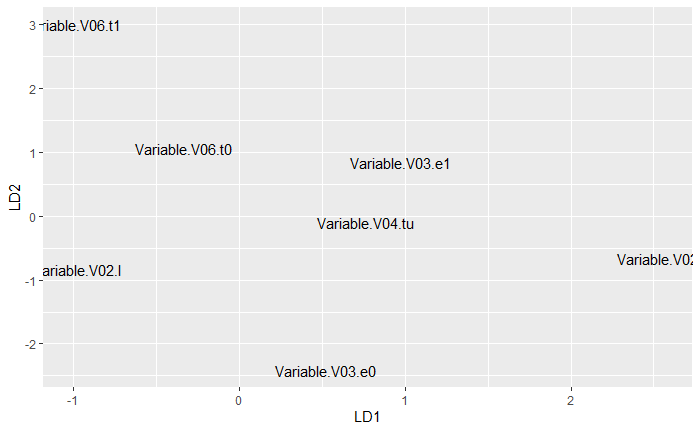

```r
V5SumMa4LDAScal <- as.data.frame(V5SumMa4LDA$scaling)
V5SumMa4LDAScal[,3] <-V5SumMa4LDAScal$LD1- V5SumMa4LDAScal$LD2
ggplot(data=V5SumMa4LDAScal, aes(x=LD1, y=LD2))+geom_text(aes(label=rownames(V5SumMa4LDAScal)))
```

```r
# Vars <- colnames(AnalyseV5)
# AnalyseV5 <- V5[,which(colSums(AnalyseV5)>0)]
SortIpV5[is.na(SortIpV5)] <- 0 #NA durch 0 ersetzen
```

[output not shown]

```r
#Vars <- colnames(SortIpV5)
#f <- paste(Vars[39], "~", paste(Vars[-c(1:2,5:15,39)], collapse=" + "))
#corV5 <- cor(AnalyseV5[,-c(13,16:17,22:24,35,36)])
#V5LDA <- lda(as.formula(paste(f)),data=SortIpV5, prior=c(36,42,23,30)/131)
priors <- count(SortIpV5, group)
priors <- c(priors$n)
V5GlobLDA <- lda( SortIpV5[,-c(1:15,32,39)],SortIpV5$group, prior = priors/nrow(SortIpV5))
```

[output not shown]

Lemma als Kategorie

```r
dummiesLemma <- as.data.frame(dummies::dummy("lemma",V5, sep=":")) #create binary values of variable
dummiesTAG <- as.data.frame(dummies::dummy("tag",V5, sep=":"))
dummiesLemma <- cbind(dummiesLemma,dummiesTAG)
#dummiesLEMMA<- as.data.frame(dummies::dummy("lemma",Corpus, sep=":")) #create binary values of variable
for (i in nrow(V5):2) {
  if(V5[i,1]==V5[i-1,1] & V5[i,"EventNumber"]!= V5[i-1,"EventNumber"]){
    dummiesLemma[i-1,] <- dummiesLemma[i-1,]+dummiesLemma[i,] # add up variable values
    dummiesLemma <- dummiesLemma[-i, ]
  }else if(V5[i,1]==V5[i-1,1] & V5[i,"EventNumber"]==V5[i-1,"EventNumber"]){
    dummiesLemma[i-1,] <- dummiesLemma[i-1,]+dummiesLemma[i,] # add up variable values
    dummiesLemma <- dummiesLemma[-i, ]
  }
}
#in Prozent umrechnen
    Sums <- unname(rowSums(dummiesLemma)) # get RowSums
          for (n in 1:nrow(dummiesLemma)){
        if(Sums[n] !=0){
          for (l in 1:ncol(dummiesLemma)){
            dummiesLemma[n,l] <- as.numeric(dummiesLemma[n,l])
            dummiesLemma[n,l] <- dummiesLemma[n,l]/Sums[n] # get percentage
          }
        }
          }
V5IpTag <- bind_cols(SortIpV5,dummiesLemma)
```

Plot by situation with Cooccurrence and Tag

```r
files <- unique(V5IpTag$File)
for (k in 1:length(files)) {
  g <- filter(V5IpTag, V5IpTag$File==files[k])
    for (p in 1:ncol(g)) {
      g[,p] <- as.factor(g[,p])
    }
  name <- stringr::str_glue("V5IpTag",stringr::str_trim(files[k]))
  assign(name,g)
}
#Gewichtung aller Variablen und der Wortart gleich um Variantenreichtum rauszurechnen
#c(0.055,0.055,0.055,0.055,0.055,0.055,0.055,0.055,0.055,0.055,0.055,0.055,0.277,0.277,0.277,0.277,0.055,0.055,0.012,0.012,0.012,0.012,0.012,0.012,0.012,0.012,0.012)
#Ma1
com_clust(V5IpTagMa1)
com_clust(V5IpTagMa2)
com_clust(V5IpTagMa4)
```

[output not shown]

find best combination

```r
#find variables without variation
V5IpTagNum <- V5IpTag
for (k in 1:ncol(V5IpTag)) {
  V5IpTagNum[,k] <- as.numeric(V5IpTagNum[,k])
}
V5IpTagOhneNull <- select_if(V5IpTagNum, sum()!=0)

V5IpTagOhneNull <- V5IpTagNum[,-(which(colSums(V5IpTagNum)==0))]
colsum <- colSums(V5IpTagNum, na.rm = TRUE)
find_comb <- function(data, variables){

}
```

```r
cor <- cor(V5Summary[,-c(1)])
V5PCA <- PCA(V5Summary[,-1], quali.sup = 1)
dimdesc(V5PCA, axes = 1:2)
plot(V5PCA)
V5Ma1PCA$ind

#PCA(V5Summary[,-c(1)], quali.sup = 1)
```

[output not shown]

```r
# Vars <- colnames(AnalyseV5)
# AnalyseV5 <- V5[,which(colSums(AnalyseV5)>0)]
Vars <- colnames(AnalyseV5)
f <- paste(Vars[10], "~", paste(Vars[-c(10,4)], collapse=" + "))
#corV5 <- cor(AnalyseV5[,-c(13,16:17,22:24,35,36)])
#get priors
priors <- count(AnalyseV5, group)
priors <- c(priors$n)
#for k in nrow(priors){}
V5LDA <- lda(AnalyseV5[,-c(3,19)],AnalyseV5$group, prior=priors/nrow(AnalyseV5))
V5LDA
plot(V5LDA)
V5LDAScal <- as.data.frame(V5SumMa4LDA$scaling)
V5LDAScal[,3] <-V5LDAScal$LD1- V5LDAScal$LD2
```

[output not shown]